# Loading and preprocessing the data

## Loading and preprocessing the data

```r
Sys.setlocale("LC_TIME", "C")
```

[1] “C”

```r
dataFileNAme="activity.zip"
unzip(dataFileNAme)
reprodata <- read.csv("activity.csv",header = TRUE)
totalStepPerDay <- sapply(split(reprodata,reprodata$date),function(x) sum(x$steps,na.rm=TRUE))
medianStepPerDay <- median(totalStepPerDay,na.rm=TRUE)
meanStepPerDay <- mean(totalStepPerDay,na.rm=TRUE)

vmedian_text=paste("median: ",medianStepPerDay)
vmean_text=paste("mean: ",meanStepPerDay)
library(reshape2)

reprodataReshaped=melt(reprodata[,c("interval","steps")],id="interval", measure.vars=c("steps"),variable.name="steps", na.rm=TRUE)
reprodataMean= dcast(reprodataReshaped, interval~ steps,mean)


require(ggplot2)
require(plyr)
```

## What is mean total number of steps taken per day?

1. Make a histogram of the total number of steps taken each day

[figure not shown]

```r
hist(totalStepPerDay,col="light green",main="Histogram Total number of steps taken per day", xlab="steps")
abline(v=meanStepPerDay,col="red")
abline(v=medianStepPerDay,col="blue")
legend("topright", cex=0.5,col=c("red","blue"), lty=c(1,1), legend=c(vmedian_text,vmean_text))
```

1. Calculate and report the mean and median total number of steps taken per day

   Median is:

```r
medianStepPerDay
```

[1] 10395

Mean is:

```r
meanStepPerDay
```

```
## [1] 9354
```

## What is the average daily activity pattern?

1. Make a time series plot (i.e. type = “l”) of the 5-minute interval (x-axis) and the average number of steps taken, averaged across all days (y-axis)

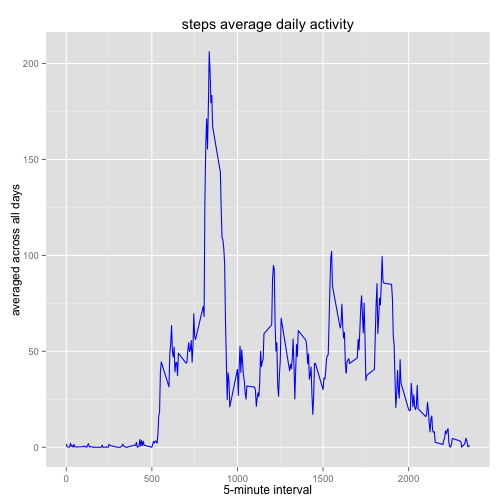

```r
ggplot(reprodataMean, aes(interval,steps)) + geom_line(color="blue")+ labs(title="steps average daily activity")+ labs(x="5-minute interval")+ labs(y="averaged across all days")
```

1. Which 5-minute interval, on average across all the days in the dataset, contains the maximum number of steps?

   Interval with maximal number of steps:

```r
max <- reprodataMean[reprodataMean$steps ==max(reprodataMean$steps),]

max$interval[1]
```

```
## [1] 835
```

## Imputing missing values

1. Calculate and report the total number of missing values in the dataset (i.e. the total number of rows with NAs)

```r
numberOfNa <- length(which((is.na(reprodata))))
numberOfNa
```

```
## [1] 2304
```

1. Strategy for filling in all of the missing values in the dataset:

```
- The missing value will be replaced with the mean for that 5-minute interval.
```

1. Create a new dataset that is equal to the original dataset but with the missing data filled in.

```r
reprodataFilled <- reprodata
numRow <- nrow(reprodataFilled)
j =1
numberOfReplacedNa=0
for(i in 1:numRow){

  if(is.na(reprodataFilled$steps[i])){
    reprodataFilled$steps[i] = reprodataMean$steps[j]
     numberOfReplacedNa=numberOfReplacedNa+1
  }
  j=j+1
  if(j==289){
    j=1
  }
}
head(reprodataFilled,n=10)
```

```
##      steps       date interval
## 1  1.71698 2012-10-01        0
## 2  0.33962 2012-10-01        5
## 3  0.13208 2012-10-01       10
## 4  0.15094 2012-10-01       15
## 5  0.07547 2012-10-01       20
## 6  2.09434 2012-10-01       25
## 7  0.52830 2012-10-01       30
## 8  0.86792 2012-10-01       35
## 9  0.00000 2012-10-01       40
## 10 1.47170 2012-10-01       45
```

1. Make a histogram of the total number of steps taken each day

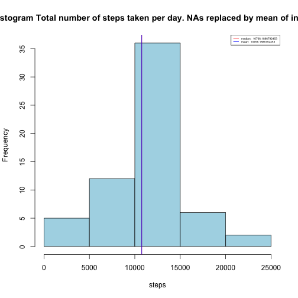

```r
totalStepPerDayFilled <- sapply(split(reprodataFilled,reprodataFilled$date),function(x) sum(x$steps,na.rm=FALSE))

medianStepPerDayFil <- median(totalStepPerDayFilled,na.rm=TRUE)
meanStepPerDayFil <- mean(totalStepPerDayFilled,na.rm=TRUE)

vmedian_text=paste("median: ",medianStepPerDayFil)
vmean_text=paste("mean: ",meanStepPerDayFil)



hist(totalStepPerDayFilled,col="light blue",main="Histogram Total number of steps taken per day. NAs replaced by mean of interval.", xlab="steps")
abline(v=meanStepPerDayFil,col="red")
abline(v=medianStepPerDayFil,col="blue")
legend("topright", cex=0.4,col=c("red","blue"), lty=c(1,1), legend=c(vmedian_text,vmean_text))
```

- Calculate and report the mean and median total number of steps taken per day. Mean is :

```r
meanStepPerDayFil
```

```
## [1] 10766
```

Median is:

```r
medianStepPerDayFil
```

```
## [1] 10766
```

- Do these values differ from the estimates from the first part of the assignment?

The values differ from those estimated in the first part:

Mean after approximation greater than mean before Approximation?

```r
meanStepPerDayFil > meanStepPerDay
```

```
## [1] TRUE
```

Median after approximation greater than median before Approximation?

```r
medianStepPerDayFil> medianStepPerDay
```

```
## [1] TRUE
```

## Are there differences in activity patterns between weekdays and weekends?

- Create a new factor variable in the dataset with two levels – “weekday” and “weekend” indicating whether a given date is a weekday or weekend day.

```r
weekDays<-c("Monday","Tuesday","Wednesday","Thursday","Friday")
#weekEnd <-c("Saturday","Sunday")

reprodataFilled <-transform(reprodataFilled,daytype = factor( x=ifelse(weekdays(as.Date(reprodataFilled$date)) %in% weekDays,"weekday","weekend"),levels = c("weekday","weekend") ))
summary(reprodataFilled)
```

```
##      steps               date          interval       daytype
##  Min.   :  0.0   2012-10-01:  288   Min.   :   0   weekday:12960
##  1st Qu.:  0.0   2012-10-02:  288   1st Qu.: 589   weekend: 4608
##  Median :  0.0   2012-10-03:  288   Median :1178
##  Mean   : 37.4   2012-10-04:  288   Mean   :1178
##  3rd Qu.: 27.0   2012-10-05:  288   3rd Qu.:1766
##  Max.   :806.0   2012-10-06:  288   Max.   :2355
##                  (Other)   :15840
```

```r
head(reprodataFilled)
```

```
##     steps       date interval daytype
## 1 1.71698 2012-10-01        0 weekday
## 2 0.33962 2012-10-01        5 weekday
## 3 0.13208 2012-10-01       10 weekday
## 4 0.15094 2012-10-01       15 weekday
## 5 0.07547 2012-10-01       20 weekday
## 6 2.09434 2012-10-01       25 weekday
```

```r
copyFilled <- reprodataFilled
copymelt <-  melt(copyFilled ,id=c("interval","date"), measure.vars=c("steps"),variable.name="steps", na.rm=TRUE)

copymeltMutate<-mutate(copymelt,daytype = factor( x=ifelse(weekdays(as.Date(copymelt$date)) %in% weekDays,"weekday","weekend"),levels = c("weekday","weekend") ))

copymeltMean= dcast(copymeltMutate, interval+daytype ~ steps,mean)
```

and then make the panel plot:

```
## geom_smooth: method="auto" and size of largest group is <1000, so using loess. Use 'method = x' to change the smoothing method.
## geom_smooth: method="auto" and size of largest group is <1000, so using loess. Use 'method = x' to change the smoothing method.
```

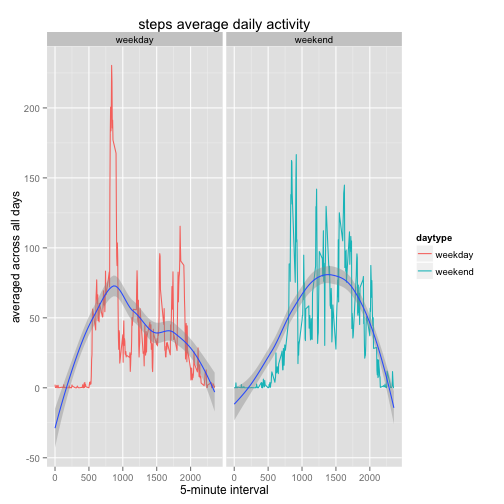

```r
#  qplot(interval,value,data=reprodataFilledReshaped,facets= daytype ~ .,geom =c("line","smooth"),color=daytype)
# require(lattice)
# xyplot(reprodataFilledReshaped$value ~ reprodataFilledReshaped$interval | reprodataFilledReshaped$daytype, layout=c(2,1))


ggplot(copymeltMean, aes(interval,steps)) + geom_line(aes(color = daytype))+geom_smooth(method="auto")+facet_grid(. ~ daytype)+ labs(title="steps average daily activity")+ labs(x="5-minute interval")+ labs(y="averaged across all days")
```